# R Notebook

# Loading in Libraries

```r
library(tidyverse)
library(cluster)
library(factoextra)
library(dendextend)
library(broom)
library(animation)
library(janitor)
library(cluster)
library(GGally)
```

# Reading in and Cleaning data

```r
mall_data <- read_csv("mall_customers.csv") %>%
  clean_names() %>%
  rename(spending_score = spending_score_1_100,
         annual_income = annual_income_k)
```

# Initial Exploratory Analysis of Data

```r
summary(mall_data)
head(mall_data)

mall_data %>%
  group_by(gender) %>%
  summarise(n())

mall_data %>%
  summarise(max(age))

mall_data %>%
  summarise(min(age))

ggplot(mall_data) +
  aes(x = age) +
  geom_histogram(bins = 10)
```

[output not shown]

There are 5 columns, customer_id appears to be just an id column. The data also seems to be already scaled as the annual_income has been divided by 1000. There appears to be an unbalance between female and male customers.The customer age range is 18-70 and there’s a fairly bimodal distribution of these ages.

# Plotting data

```r
ggpairs(mall_data, progress = FALSE)
```

[output not shown]

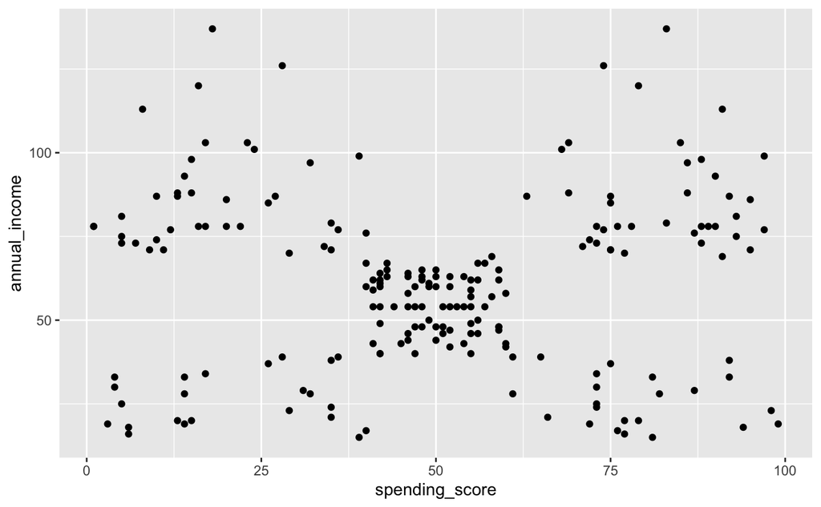

```r
ggplot(mall_data) +
  aes(x = spending_score, y = annual_income) +
  geom_point()
```

There is potential evidence of clustering after plotting spending_score and annual_income. K-means clustering is an ideal technique to try identfify meaningful clusters in the data to target the customers.

# Selecting only spending_score and annual_income

```r
mall_data_trim <- mall_data %>%
  select(annual_income, spending_score)
```

# Choosing a k_value

3 methods will be used to identitfy the optimal k value - elbow method, silhoulette coefficient and gap statistic.

## Elbow

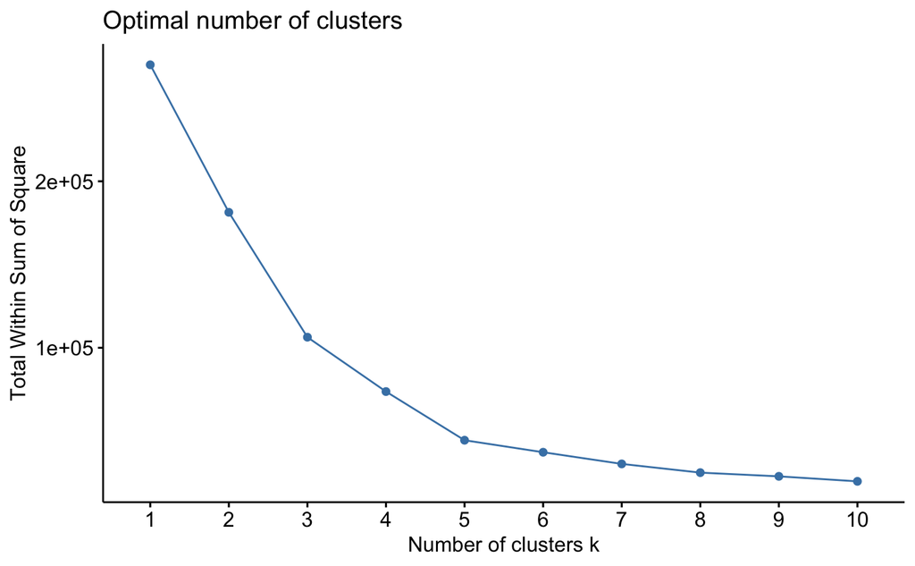

```r
fviz_nbclust(mall_data_trim, kmeans, method = "wss", nstart = 25)
```

The elbow indicates that the optimal k-value could be either 3 or 5.

## Silhouette

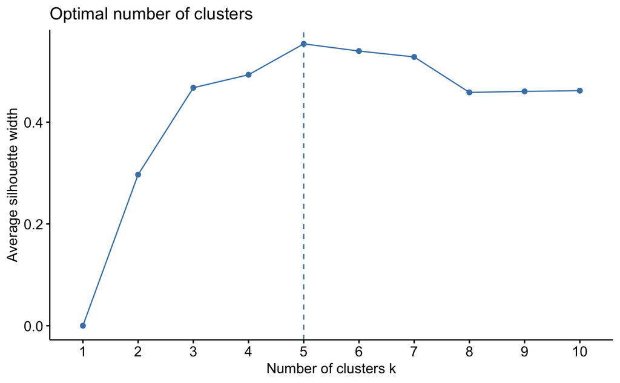

```r
fviz_nbclust(mall_data_trim, kmeans, method = "silhouette", nstart = 25)
```

The Silhouette method indicates that the optimal k-value is 5.

## Gap

```r
fviz_nbclust(mall_data_trim, kmeans, method = "gap_stat", nstart = 25, k.max = 10)
```

[output not shown]

Gap statistic shows that 1 should be the k-value

Based on results from all 3 methods, 5 is the most common number to have been identified as optimal so I will proceed with this number.

# K means clustering

```r
clustered_mall_data <- kmeans(mall_data_trim, 5, nstart = 25)

clustered_mall_data$size

clustered_mall_data$centers
```

# K means visualisation

```r
clusters <- augment(clustered_mall_data, mall_data)

ggplot(clusters, aes(x = spending_score, y = annual_income, colour = .cluster)) +
  geom_point() +
  labs(x = "Spending Score (out of 100)", y = "Annual Income (k)")
```

[output not shown]

From the visualisation it can be said there is evidence that the among the customer data there are 5 distinct groupings. Generally there appears to be little spread of data points within each cluster and this indicates that the clustering is a good fit.

# Labelling cluster 5

Within all 5 clusters there looks to be a commonality in attributes but this is particularly evident in the central purple cluster, cluster 5.

# Labelling Cluster 5

```r
cluster_5 <- clusters %>%
  filter(.cluster == "5")
```

| customer_id | gender | age | annual_income | spending_score | .cluster |
| --- | --- | --- | --- | --- | --- |
| 44 | Female | 31 | 39 | 61 | 5 |
| 47 | Female | 50 | 40 | 55 | 5 |
| 48 | Female | 27 | 40 | 47 | 5 |
| 49 | Female | 29 | 40 | 42 | 5 |
| 50 | Female | 31 | 40 | 42 | 5 |
| 51 | Female | 49 | 42 | 52 | 5 |
| 52 | Male | 33 | 42 | 60 | 5 |
| 53 | Female | 31 | 43 | 54 | 5 |
| 54 | Male | 59 | 43 | 60 | 5 |
| 55 | Female | 50 | 43 | 45 | 5 |

[output cut: 71 more lines]

```r
cluster_5_gender <- cluster_5 %>%
  group_by(gender) %>%
  summarise(count = n()) %>%
  mutate(gender_percent = round(count/sum(count), digits = 3) * 100)

cluster_5_gender
```

[output not shown]

```r
cluster_5_averages <- cluster_5 %>%
  summarise(average_age = round(mean(age), digits = 1),
            average_income = round(mean(annual_income), digits = 2),
            average_spending_score = round(mean(spending_score), digits = 1))

cluster_5_averages
```

[output not shown]

```r
mode_age <- cluster_5 %>%
  group_by(age) %>%
  summarise(count = n()) %>%
  arrange(desc(count)) %>%
  head(3)
```

Cluster 5